# Analiza medijske pokrivenosti inflacije u Hrvatskoj

Author

GIMES Research

Published

2. siječnja 2026.

# 1 Uvod

U ovom izvještaju se predstavlja sveobuhvatna analiza medijske pokrivenosti inflacije u Hrvatskoj. Analizom se obuhvaća praćenje inflacijskih tema, cijena, troškova života, energetskih cijena i monetarne politike temeljem članaka iz hrvatskih online medija.

## 1.1 Motivacija i kontekst

Inflacija je tijekom 2022. i 2023. godine postala središnja tema ekonomske rasprave u Hrvatskoj i šire. Ovim izvještajem se nastoji odgovoriti na ključna pitanja:

1. Kako se medijsko izvještavanje o inflaciji razvijalo kroz vrijeme?
2. Je li medijska pozornost odgovarala stvarnim inflacijskim pritiscima?
3. Može li se medijska pozornost koristiti kao prediktor ili rani indikator inflacije?
4. Koje su teme i aspekti inflacije najzastupljeniji u medijima?

## 1.2 Struktura izvještaja

U izvještaju se obrađuju sljedeće teme: metodologija identifikacije relevantnih članaka, eksploratorni pregled dataseta, semantička taksonomija inflacijskih pojmova, konstrukcija specijaliziranih indeksa, vizualizacija indeksa, sektorska analiza, sentiment analiza, volatilnost i momentum, koncentracija tema te validacija sa službenim Eurostat HICP podacima.

```
Učitano 46,107 članaka
```

```
Vremenski raspon: 01.01.2021 do 08.01.2024
```

# 2 Metodologija identifikacije članaka

## 2.1 Pregled procesa filtriranja

Identifikacija relevantnih članaka se provodi kroz sedmostupanjski proces filtriranja koji kombinira strukturne kriterije, ključne riječi i kontekstualnu validaciju. Procesom se osigurava da u analizu ulaze samo članci koji su stvarno relevantni za hrvatsku inflacijsku tematiku.

**Detaljna metodologija filtriranja**

**Filter 1: Tip izvora**

Odabiru se samo web izvori kako bi se osigurala konzistentnost formata i dostupnost punog teksta članka.

**Filter 2: Relevantni news portali**

Koristi se lista verificiranih hrvatskih news portala kategoriziranih u pet skupina: nacionalni mediji, poslovni mediji, regionalni mediji, specijalizirani mediji i opinion portali.

**Filter 3: Minimalna duljina teksta**

Članci moraju sadržavati minimalno 500 znakova u punom tekstu kako bi se osigurala sadržajna relevantnost.

**Filter 4: Naslov članka**

Naslov članka mora sadržavati inflacijske pojmove definirane regularnim izrazima koji obuhvaćaju morfološke varijante.

**Filter 5: Core inflacijski pojmovi**

Puni tekst članka mora sadržavati core inflacijske pojmove koji potvrđuju da se članak bavi inflacijskom tematikom.

**Filter 6: Isključivanje irelevantnog sadržaja**

Isključuju se članci koji ne tretiraju inflaciju kao primarnu temu.

**Filter 7: Hrvatski kontekst**

Članci moraju sadržavati reference na hrvatsku ekonomiju (Hrvatska, hrvatski, HNB, eurozona HR kontekst).

# 3 Eksploratorni pregled podataka

## 3.1 Osnovne statistike

Osnovne statistike dataseta

| Metrika | Vrijednost |
| --- | --- |
| Ukupan broj članaka | 46,107 |
| Vremenski raspon | 01.01.2021 do 08.01.2024 |
| Broj dana | 1102 |
| Prosječno članaka dnevno | 41.8 |
| Broj izvora (portala) | 115 |
| Broj kategorija izvora | 5 |

## 3.2 Distribucija po kategorijama izvora

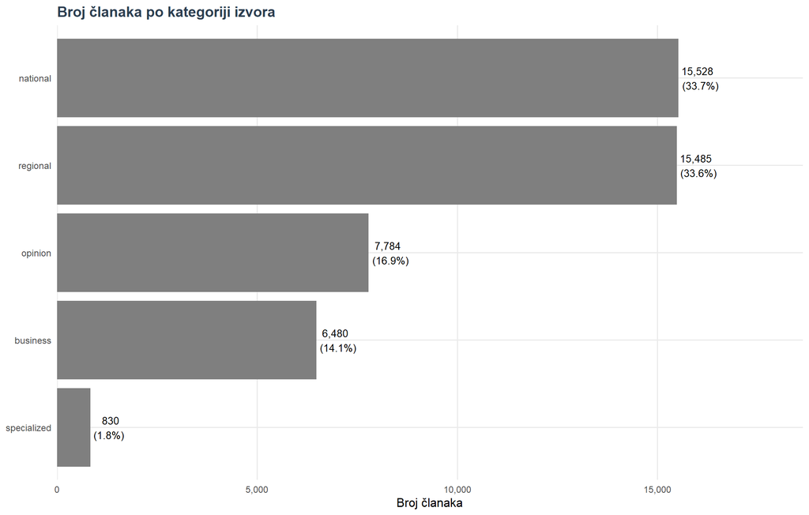

Distribucija članaka po kategorijama izvora

## 3.3 Top 20 izvora

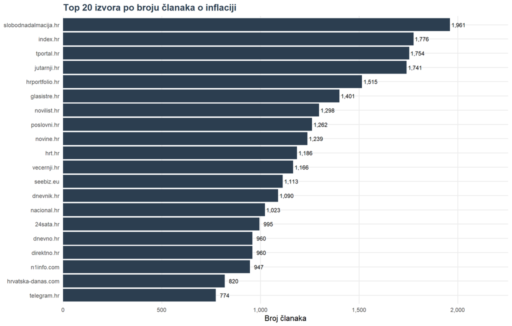

20 najaktivnijih izvora

## 3.4 Distribucija duljine teksta

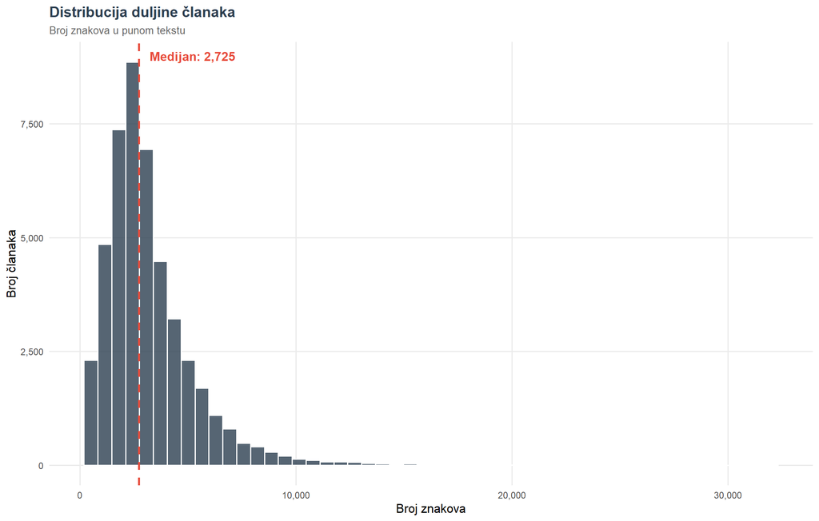

Distribucija duljine članaka

# 4 Semantička taksonomija

## 4.1 Hijerarhijska struktura pojmova

Semantička taksonomija se organizira u osam kategorija koje obuhvaćaju različite aspekte inflacije. Svaka kategorija predstavlja specifičan sektor ili tematsko područje vezano uz inflaciju. Pojmovi se definiraju pomoću korijena riječi (stem) kako bi se osigurala šira morfološka pokrivenost hrvatskog jezika.

**Detaljna metodologija semantičke taksonomije**

**Princip konstrukcije rječnika:**

1. Kategorije predstavljaju konceptualno različite aspekte inflacije
2. Regex uzorci se koriste za fleksibilno prepoznavanje morfoloških varijanti
3. Korijenski oblici osiguravaju prepoznavanje svih padežnih i glagolskih oblika

**Formula za brojanje:**

$$\text{count}_{c,d} = \sum_{p \in P_c} \text{matches}(p, d)$$

gdje je $P_c$ skup regex uzoraka za kategoriju $c$, a $d$ je tekst dokumenta.

Pregled rječnika semantičkih pojmova za inflaciju

| Kategorija | Broj pojmova | Primjeri regex uzoraka |
| --- | --- | --- |
| Inflacija (direktno) | 4 | inflacij[a-zčćžšđ]*, dezinflacij[a-zčćžšđ]* |
| Cijene i poskupljenja | 8 | poskupljenj[a-zčćžšđ]*, poskupi[a-zčćžšđ]* |
| Troškovi života | 4 | tro[sš]kov[a-zčćžšđ]*.{0,10}[zž]ivot[a-zčćžšđ]*, [zž]ivotn[a-zčćžšđ]*.{0,10}standard[a-zčćžšđ]* |
| Energija i gorivo | 5 | cijen[a-zčćžšđ]*.{0,10}energij[a-zčćžšđ]*, cijen[a-zčćžšđ]*.{0,10}goriv[a-zčćžšđ]* |
| Hrana | 5 | cijen[a-zčćžšđ]*.{0,10}hran[a-zčćžšđ]*, cijen[a-zčćžšđ]*.{0,10}namirnic[a-zčćžšđ]* |
| Monetarna politika | 6 | kamatn[a-zčćžšđ]*.{0,10}stop[a-zčćžšđ]*, kamat[a-zčćžšđ]* |
| Plaće i primanja | 5 | pla[cć][a-zčćžšđ]*, primanj[a-zčćžšđ]* |
| Indeksi i mjere | 5 | \bhicp\b, indeks.{0,10}potro[sš][a-zčćžšđ]* |

## 4.2 Brojanje semantičkih pojmova

## 4.3 Dinamika semantičkih kategorija

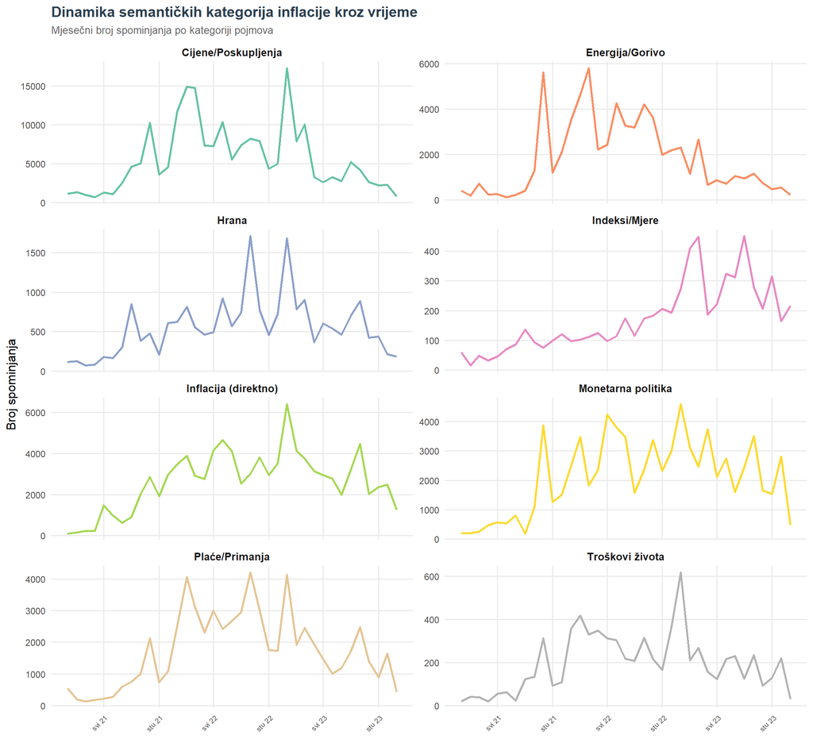

Dinamika semantičkih kategorija kroz vrijeme

# 5 Konstrukcija indeksa

### 5.0.1 Volume Inflation Index (VII)

VII kvantificira obujam medijskog izvještavanja o inflaciji mjeren brojem objavljenih članaka. Konstrukcija se temelji na prebrojavanju članaka koji su prošli filter relevantnosti za inflacijsku tematiku. Mjesečni broj članaka normalizira se na raspon 0 do 100 standardnom min max normalizacijom. Povišene vrijednosti VII indeksa indiciraju razdoblja intenzivnog medijskog izvještavanja o inflaciji.

**Detaljna metodologija VII indeksa**

**Formula:**

$$\text{VII}_t = \text{normalize}_{0-100}(N_t)$$

gdje je $N_t$ broj članaka u mjesecu $t$.

**Interpretacija:** Visoke vrijednosti ukazuju na veliku količinu medijskog sadržaja o inflaciji.

### 5.0.2 Semantic Inflation Index (SII)

SII mjeri intenzitet korištenja inflacijske terminologije u medijskom diskursu. Indeks se konstruira zbrajanjem pojavljivanja svih semantičkih pojmova iz svih kategorija normaliziranih brojem članaka. Viša vrijednost indicira dublju i analitičniju obradu inflacijske tematike u medijima.

**Detaljna metodologija SII indeksa**

**Formula:**

$$\text{SII}_t = \text{normalize}_{0-100}\left(\frac{\sum_{c} \text{count}_{c,t}}{N_t}\right)$$

**Uključene kategorije:** inflacija direktno, cijene i poskupljenja, troškovi života, energija i gorivo, hrana, monetarna politika, plaće i primanja, indeksi i mjere

### 5.0.3 Sentiment Inflation Index (SAI)

SAI mjeri ton medijskog izvještavanja o inflaciji na skali od negativnog (zabrinutost, kriza) do pozitivnog (stabilizacija, oporavak). Konstrukcija se temelji na leksičkom pristupu koji broji pozitivne i negativne pojmove u tekstu. Sentiment svakog članka se izračunava kao normalizirana razlika pozitivnih i negativnih pojmova, a mjesečna vrijednost predstavlja prosjek sentimenta svih članaka.

**Detaljna metodologija SAI indeksa**

**Formula za članak:**

$$S_d = \frac{P_d - N_d}{P_d + N_d + 1}$$

gdje je $P_d$ broj pozitivnih pojmova, $N_d$ broj negativnih pojmova.

**Mjesečna agregacija:**

$$\text{SAI}_t = \text{normalize}_{0-100}(\bar{S}_t)$$

**Napomena:** Za GIMES indeks se koristi invertirana vrijednost (100 minus SAI) tako da viša vrijednost indicira veću zabrinutost.

### 5.0.4 GIMES Composite Index (GCI)

GCI predstavlja kompozitni indeks koji kombinira četiri dimenzije medijskog izvještavanja o inflaciji. Indeks agregira volumen izvještavanja, intenzitet analize (duljina članaka), ton sentimenta i doseg članaka. Težine komponenti su: volumen 40%, intenzitet 20%, sentiment 20% i doseg 20%. Viša vrijednost indicira veću ukupnu medijsku pozornost i zabrinutost oko inflacije.

**Detaljna metodologija GCI indeksa**

**Formula:**

$$\text{GCI}_t = 0.40 \times V_{norm,t} + 0.20 \times I_{norm,t} + 0.20 \times (100 - S_{norm,t}) + 0.20 \times R_{norm,t}$$

gdje su: V = normalizirani volumen članaka, I = normalizirani intenzitet (prosječna duljina), S = normalizirani sentiment (invertiran), R = normalizirani doseg (reach)

**Interpretacija vrijednosti:**

Raspon 0 do 25 indicira nisku medijsku pozornost na inflaciju. Raspon 25 do 50 indicira umjerenu medijsku pozornost. Raspon 50 do 75 indicira visoku medijsku pozornost. Raspon 75 do 100 indicira vrlo visoku medijsku pozornost tipičnu za krizna razdoblja.

## 5.1 Opis indeksa

Pregled konstruiranih indeksa

| Indeks | Naziv | Opis |
| --- | --- | --- |
| VII | Volume Inflation Index | Obujam medijskog izvještavanja (broj članaka) |
| SII | Semantic Inflation Index | Intenzitet korištenja inflacijske terminologije |
| SAI | Sentiment Inflation Index | Ton izvještavanja (negativan do pozitivan) |
| GCI | GIMES Composite Index | Kompozitni indeks svih dimenzija |

# 6 Vizualizacija indeksa

## 6.1 Glavni indeksi

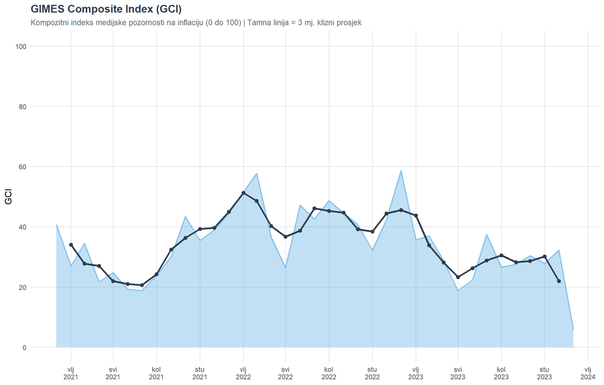

GIMES Composite Index (GCI)

## 6.2 Komponente indeksa

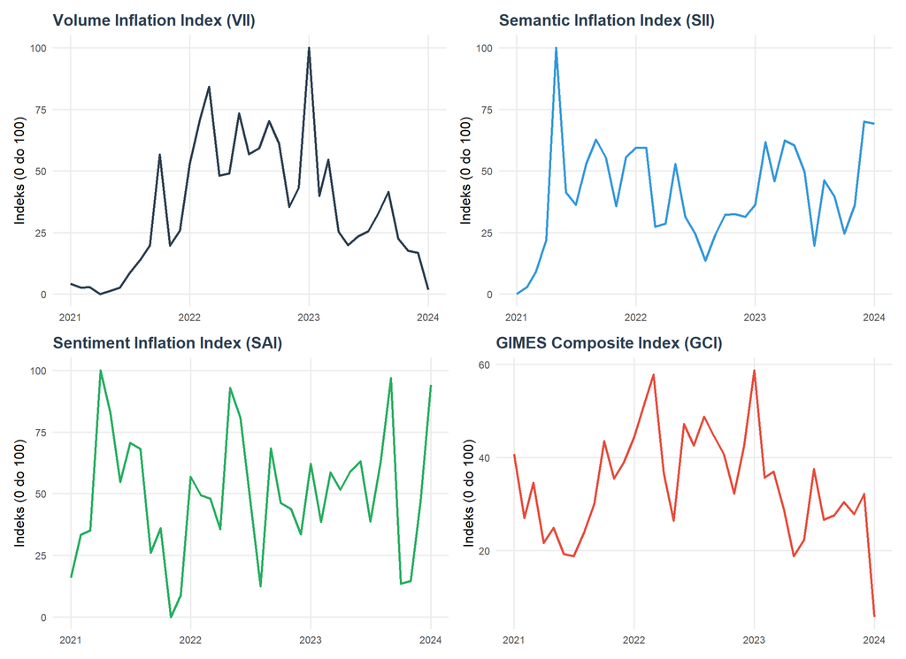

Komponente GIMES indeksa: VII, SII, SAI

## 6.3 Tablica indeksa

Indeksi inflacije: zadnjih 12 mjeseci

| Mjesec | Broj članaka | VII | SII | SAI | GCI |
| --- | --- | --- | --- | --- | --- |
| vlj 2023 | 1,405 | 40.0 | 61.6 | 38.6 | 35.7 |
| ožu 2023 | 1,848 | 54.5 | 45.9 | 58.6 | 36.9 |
| tra 2023 | 959 | 25.3 | 62.4 | 51.6 | 28.8 |
| svi 2023 | 793 | 19.9 | 60.5 | 59.0 | 18.8 |
| lip 2023 | 904 | 23.5 | 49.8 | 63.1 | 22.4 |
| srp 2023 | 964 | 25.5 | 19.8 | 38.7 | 37.5 |
| kol 2023 | 1,184 | 32.7 | 46.2 | 63.0 | 26.6 |
| ruj 2023 | 1,451 | 41.5 | 39.6 | 96.8 | 27.5 |
| lis 2023 | 874 | 22.5 | 24.6 | 13.4 | 30.5 |
| stu 2023 | 728 | 17.7 | 36.2 | 14.5 | 27.9 |
| pro 2023 | 702 | 16.9 | 70.0 | 46.9 | 32.2 |
| sij 2024 | 246 | 1.9 | 69.1 | 94.0 | 5.8 |

# 7 Sektorska analiza

## 7.1 Dinamika po sektorima

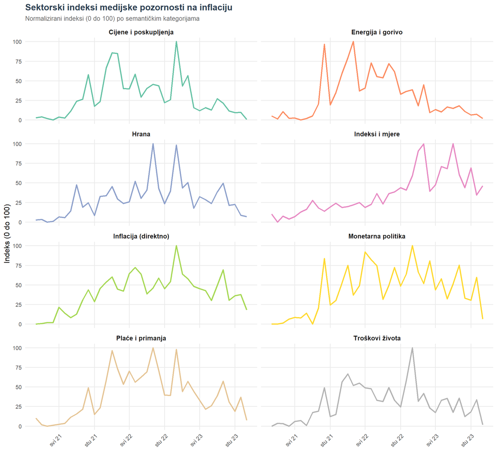

Sektorski indeksi medijske pozornosti

## 7.2 Heatmapa sektorske aktivnosti

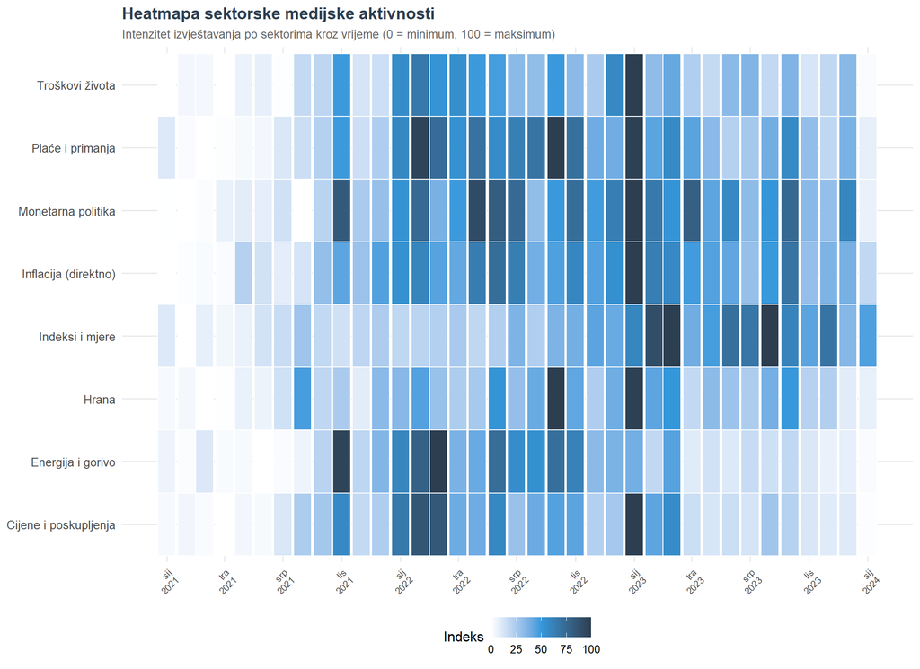

Heatmapa sektorske aktivnosti

## 7.3 Korelacijska struktura

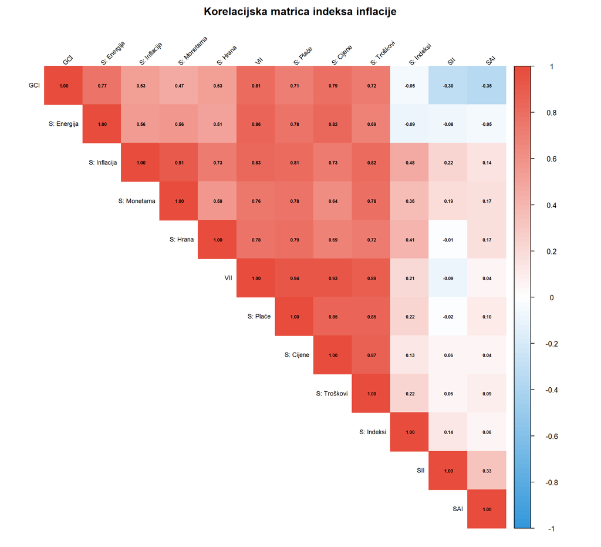

Korelacijska matrica indeksa inflacije

# 8 Sentiment analiza

## 8.1 Dinamika sentimenta kroz vrijeme

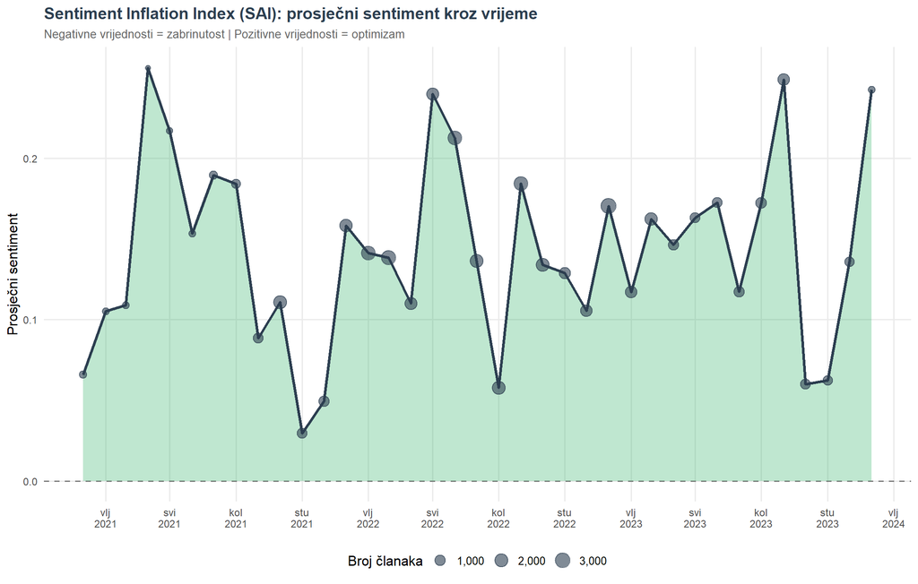

Dinamika sentimenta kroz vrijeme

## 8.2 Distribucija sentimenta

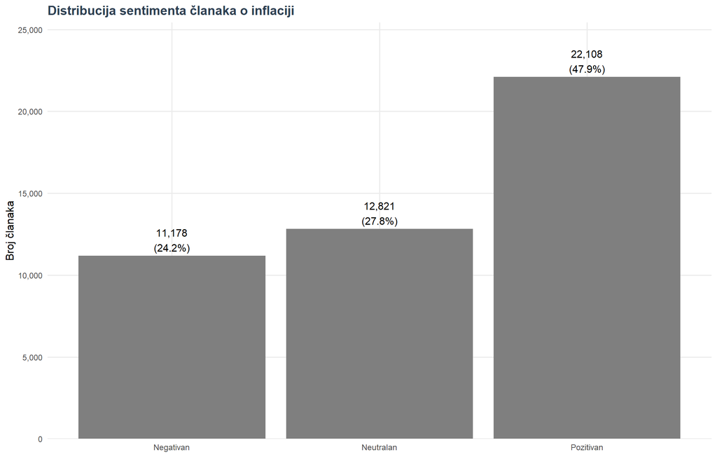

Distribucija sentimenta članaka

# 9 Volatilnost i momentum

## 9.1 Konstrukcija volatilnosti i momentuma

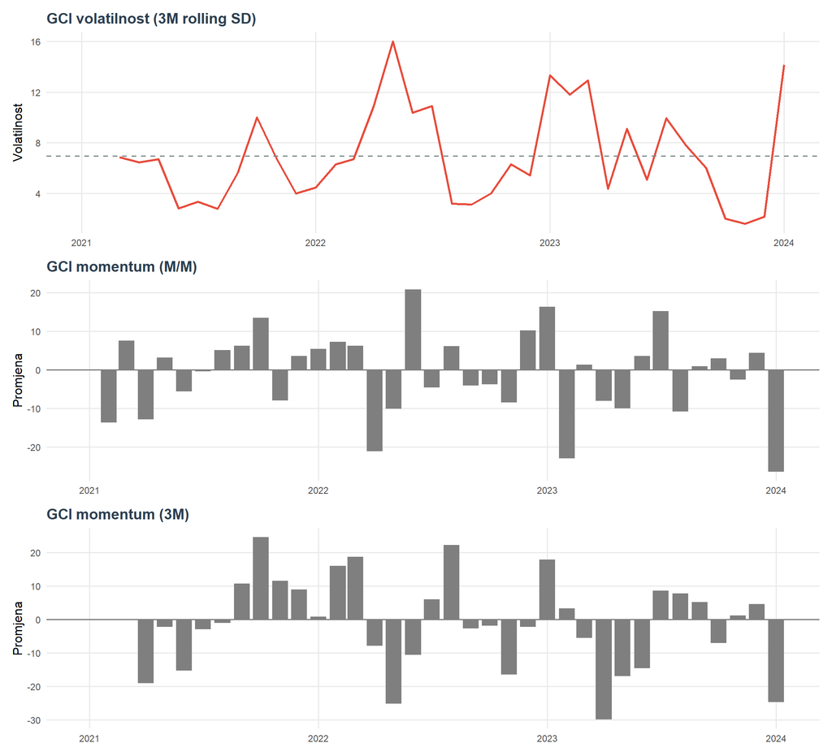

GCI volatilnost i momentum

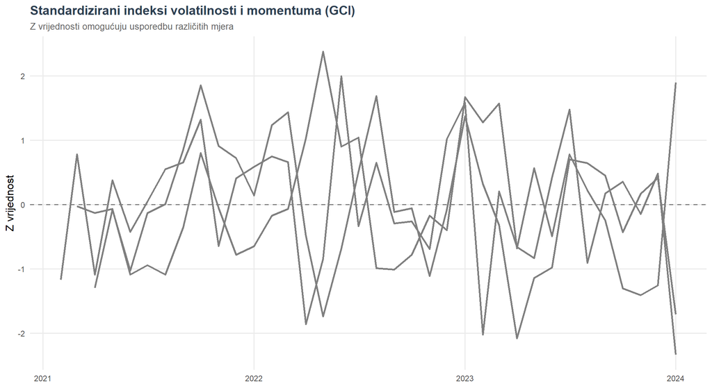

Standardizirani indeksi volatilnosti i momentuma

# 10 Koncentracija tema

## 10.1 Konstrukcija mjera koncentracije

**Metodologija HHI indeksa**

Herfindahl Hirschman Index (HHI) mjeri koncentraciju tema u medijskom prostoru. Izračunava se kao suma kvadrata udjela svake kategorije. Vrijednosti bliže 1 indiciraju visoku koncentraciju (dominacija jedne teme), dok vrijednosti bliže 0 indiciraju ravnomjerniju raspodjelu pozornosti.

**Formula:**

$$\text{HHI}_t = \sum_{i=1}^{n} s_{i,t}^2$$

gdje je $s_{i,t}$ udio kategorije $i$ u ukupnom broju spominjanja u mjesecu $t$.

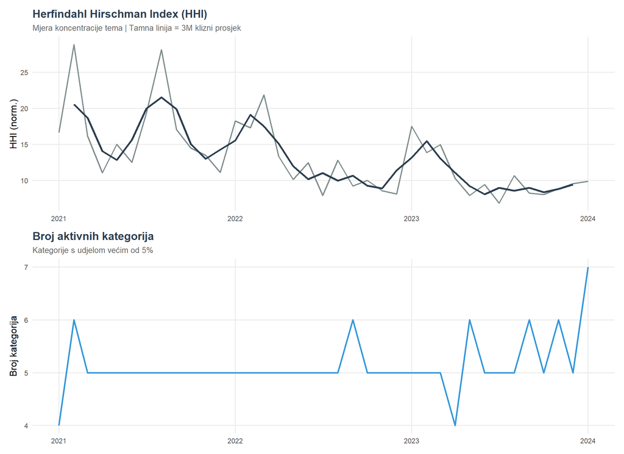

Koncentracija tema (HHI) i broj aktivnih kategorija

# 11 Validacija sa službenim podacima

## 11.1 Dohvaćanje Eurostat HICP podataka

## 11.2 GCI vs Eurostat HICP

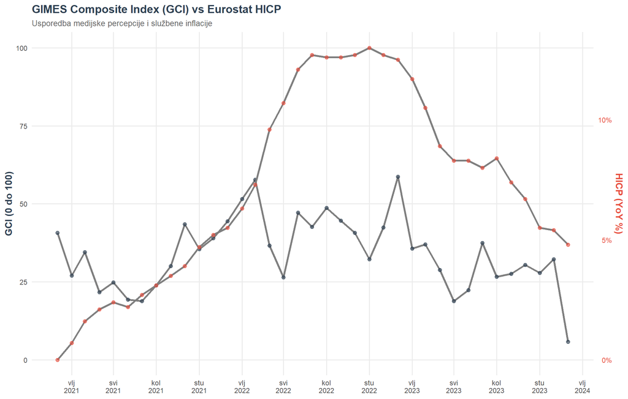

GIMES Composite Index (GCI) vs Eurostat HICP inflacija

## 11.3 Korelacije sa službenom inflacijom

Korelacije između indeksa i službene inflacije

| Usporedba | Korelacija |
| --- | --- |
| GCI vs Eurostat HICP | 0.429 |
| VII (volumen) vs Eurostat HICP | 0.723 |
| SII (semantički) vs Eurostat HICP | -0.055 |
| SAI (sentiment inv.) vs Eurostat HICP | -0.061 |

# 12 Export

# 13 Sažetak

Sažetak ključnih nalaza analize

| Nalaz | Vrijednost |
| --- | --- |
| Ukupno analiziranih članaka | 46,107 |
| Vremenski raspon analize | 01/2021 do 01/2024 |
| Broj izvora | 115 |
| Vrh GCI indeksa | siječanj 2023 |
| Vrijednost vrha | 58.7 |
| Vrh inflacije (HICP) | studeni 2022 |
| Vrijednost vrha | 13% |
| Korelacija GCI vs HICP | 0.429 |
| Prosječni GCI | 34.1 |

*Izvještaj generiran: 2026-01-02 13:37:21.174956*

*GIMES Research | Analiza medijske pokrivenosti inflacije v2.0*